# Relationship between availability of laboratory equipment and reporting rates of TB in children aged 0-14 years

Aim: Create model looking at the relationship between the number of labs in a country with TB diagnostic technology (including adjusting for estimated TB burden) and the rate of reporting of cases of TB in children aged 0-14 years.

STEP 1: Load the necessary data (laboratory data + total TB incidence data)

```r
setwd("~/Desktop/AFP/TB MODELLING 2/TB Data")
incid_data <- read_csv("TB_burden_main.csv")
incid_data <- incid_data[, c(1,3,6,7,8)]

setwd("~/Desktop/AFP/TB MODELLING 2/Resource Factors")
lab_data <- read_csv("TB_laboratories_2021-10-06.csv")
lab_data <- lab_data[, c(1,3,6,26:30)]
```

STEP 2: Refining the data

```r
lab_2019 <- filter(lab_data, year == 2019)
lab_2019 <- lab_2019[, -3]

incid_2019 <- filter(incid_data, year == 2019)
incid_2019 <- incid_2019[, -3]
```

STEP 3: Create data frame with lab data and the estimated TB incidence per year

```r
lab_incid <- cbind(lab_2019, incid_2019[, 4])
lab_adj <- mutate(lab_incid, "adj_smear" = smear/e_inc_100k, "adj_xpert" = xpert/e_inc_100k, "adj_culture" = culture/e_inc_100k)
lab_adj <- lab_adj[, c(1,2,3,9,5,6,10,7,11)]
```

STEP 4: Combining data frame with bigdata_TB to allow regression analyses to be made

```r
big_labequip <- cbind(bigdata_TB, lab_adj[, c(3:9)])
is.na(big_labequip$adj_xpert) <- sapply(big_labequip$adj_xpert, is.infinite)
is.na(big_labequip$adj_xpert) <- sapply(big_labequip$adj_xpert, is.nan)
is.na(big_labequip$adj_smear) <- sapply(big_labequip$adj_smear, is.infinite)
is.na(big_labequip$adj_smear) <- sapply(big_labequip$adj_smear, is.nan)
is.na(big_labequip$adj_culture) <- sapply(big_labequip$adj_culture, is.infinite)
is.na(big_labequip$adj_culture) <- sapply(big_labequip$adj_culture, is.nan)
```

STEP 5: Regression analyses for xpert and 0-4 years

```r
big_labequip$adj_xpert[big_labequip$adj_xpert > 15] <- NA #removing outliers

is.na(big_labequip$perc_tot014) <- sapply(big_labequip$perc_tot014, is.infinite)
is.na(big_labequip$perc_tot014) <- sapply(big_labequip$perc_tot014, is.nan)

mod_xpert_04 <- lm(big_labequip$perc_tot04 ~ big_labequip$adj_xpert)
summary(mod_xpert_04)
```

```
Call:
lm(formula = big_labequip$perc_tot04 ~ big_labequip$adj_xpert)

Residuals:
    Min      1Q  Median      3Q     Max
-61.232 -24.513  -0.942  28.784  68.184

Coefficients:
                       Estimate Std. Error t value Pr(>|t|)
(Intercept)              50.858      3.018  16.851   <2e-16 ***
big_labequip$adj_xpert    4.790      1.909   2.509   0.0133 *
---
Signif. codes:  0 ‘***’ 0.001 ‘**’ 0.01 ‘*’ 0.05 ‘.’ 0.1 ‘ ’ 1

Residual standard error: 30.3 on 131 degrees of freedom
  (82 observations deleted due to missingness)
Multiple R-squared:  0.04587,   Adjusted R-squared:  0.03858
F-statistic: 6.297 on 1 and 131 DF,  p-value: 0.01331
```

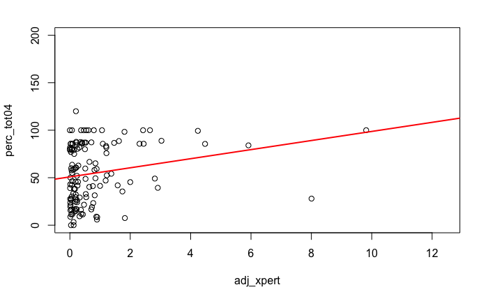

```r
plot(x = big_labequip$adj_xpert, y = big_labequip$perc_tot04, xlab = "adj_xpert", ylab = "perc_tot04")
abline(mod_xpert_04, col = "red", lwd = 2)
```

STEP 6: Regression analysis with Xpert and percentage TB diagnosis in children aged 5-14

```r
is.na(big_labequip$perc_tot514) <- sapply(big_labequip$perc_tot514, is.infinite)
is.na(big_labequip$perc_tot514) <- sapply(big_labequip$perc_tot514, is.nan)

mod_xpert_514 <- lm(big_labequip$perc_tot514 ~ big_labequip$adj_xpert)
summary(mod_xpert_514)
```

```
Call:
lm(formula = big_labequip$perc_tot514 ~ big_labequip$adj_xpert)

Residuals:
    Min      1Q  Median      3Q     Max
-53.517 -16.330  -2.684  16.107 134.666

Coefficients:
                       Estimate Std. Error t value Pr(>|t|)
(Intercept)              65.144      2.718  23.967   <2e-16 ***
big_labequip$adj_xpert    2.669      1.726   1.546    0.124
---
Signif. codes:  0 ‘***’ 0.001 ‘**’ 0.01 ‘*’ 0.05 ‘.’ 0.1 ‘ ’ 1

Residual standard error: 27.47 on 132 degrees of freedom
  (81 observations deleted due to missingness)
Multiple R-squared:  0.01779,   Adjusted R-squared:  0.01034
F-statistic:  2.39 on 1 and 132 DF,  p-value: 0.1245
```

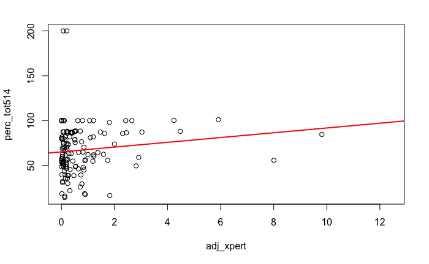

```r
plot(x = big_labequip$adj_xpert, y = big_labequip$perc_tot514, xlab = "adj_xpert", ylab = "perc_tot514")
abline(mod_xpert_514, col = "red", lwd = 2)
```

STEP 7: Regression analyses with smear and aged 0-4

```r
mod_smear_04 <- lm(big_labequip$perc_tot04 ~ big_labequip$adj_smear)
summary(mod_smear_04)
```

```
Call:
lm(formula = big_labequip$perc_tot04 ~ big_labequip$adj_smear)

Residuals:
    Min      1Q  Median      3Q     Max
-57.552 -27.653  -0.825  29.755  65.683

Coefficients:
                       Estimate Std. Error t value Pr(>|t|)
(Intercept)             54.2960     2.9071  18.677   <2e-16 ***
big_labequip$adj_smear   0.1028     0.1653   0.622    0.535
---
Signif. codes:  0 ‘***’ 0.001 ‘**’ 0.01 ‘*’ 0.05 ‘.’ 0.1 ‘ ’ 1

Residual standard error: 31.33 on 135 degrees of freedom
  (78 observations deleted due to missingness)
Multiple R-squared:  0.002855,  Adjusted R-squared:  -0.004531
F-statistic: 0.3865 on 1 and 135 DF,  p-value: 0.5352
```

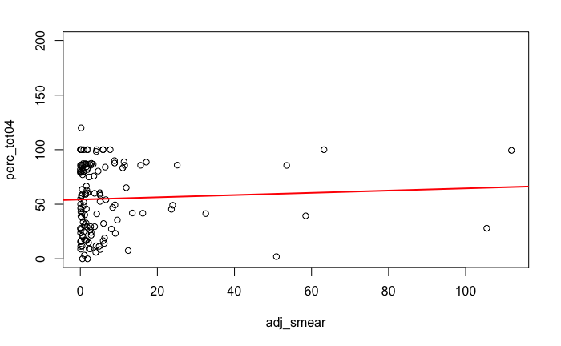

```r
plot(x = big_labequip$adj_smear, y = big_labequip$perc_tot04, xlab = "adj_smear", ylab = "perc_tot04")
abline(mod_smear_04, col = "red", lwd = 2)
```

STEP 8: Regression analysis with smear and ages 5-14 years

```r
mod_smear_514 <- lm(big_labequip$perc_tot514 ~ big_labequip$adj_smear)
summary(mod_smear_514)
```

```
Call:
lm(formula = big_labequip$perc_tot514 ~ big_labequip$adj_smear)

Residuals:
    Min      1Q  Median      3Q     Max
-52.748 -18.004  -2.424  18.609 133.124

Coefficients:
                       Estimate Std. Error t value Pr(>|t|)
(Intercept)            66.87019    2.58805  25.838   <2e-16 ***
big_labequip$adj_smear  0.08723    0.14717   0.593    0.554
---
Signif. codes:  0 ‘***’ 0.001 ‘**’ 0.01 ‘*’ 0.05 ‘.’ 0.1 ‘ ’ 1

Residual standard error: 27.89 on 135 degrees of freedom
  (78 observations deleted due to missingness)
Multiple R-squared:  0.002596,  Adjusted R-squared:  -0.004792
F-statistic: 0.3513 on 1 and 135 DF,  p-value: 0.5543
```

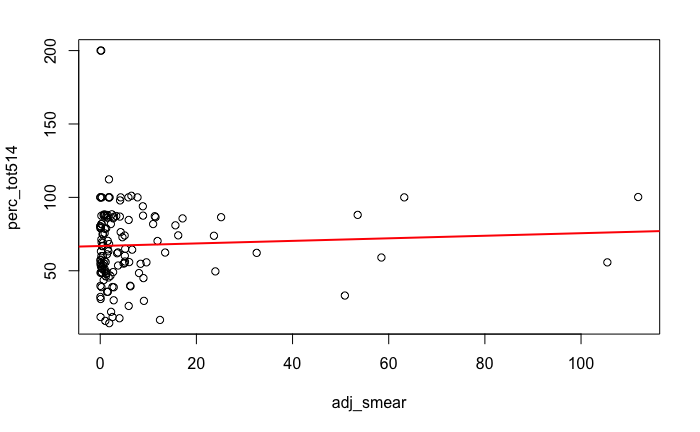

```r
plot(x = big_labequip$adj_smear, y = big_labequip$perc_tot514, xlab = "adj_smear", ylab = "perc_tot514")
abline(mod_smear_514, col = "red", lwd = 2)
```

STEP 9: Regression analysis with culture and aged 0-4 years

```r
mod_culture_04 <- lm(big_labequip$perc_tot04 ~ big_labequip$adj_culture)
summary(mod_culture_04)
```

```
Call:
lm(formula = big_labequip$perc_tot04 ~ big_labequip$adj_culture)

Residuals:
    Min      1Q  Median      3Q     Max
-76.721 -26.861   0.075  29.065  65.372

Coefficients:
                         Estimate Std. Error t value Pr(>|t|)
(Intercept)               54.5106     2.7920  19.524   <2e-16 ***
big_labequip$adj_culture   0.5888     0.6776   0.869    0.386
---
Signif. codes:  0 ‘***’ 0.001 ‘**’ 0.01 ‘*’ 0.05 ‘.’ 0.1 ‘ ’ 1

Residual standard error: 31.29 on 136 degrees of freedom
  (77 observations deleted due to missingness)
Multiple R-squared:  0.005523,  Adjusted R-squared:  -0.00179
F-statistic: 0.7552 on 1 and 136 DF,  p-value: 0.3864
```

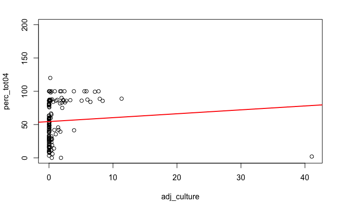

```r
plot(x = big_labequip$adj_culture, y = big_labequip$perc_tot04, xlab = "adj_culture", ylab = "perc_tot04")
abline(mod_culture_04, col = "red", lwd = 2)
```

STEP 10: Regression analysis with culture for ages 5-14 years

```r
mod_culture_514 <- lm(big_labequip$perc_tot514 ~ big_labequip$adj_culture)
summary(mod_culture_514)
```

```
Call:
lm(formula = big_labequip$perc_tot514 ~ big_labequip$adj_culture)

Residuals:
    Min      1Q  Median      3Q     Max
-53.845 -16.843  -2.394  17.126 132.672

Coefficients:
                         Estimate Std. Error t value Pr(>|t|)
(Intercept)               67.2957     2.4743  27.198   <2e-16 ***
big_labequip$adj_culture   0.4454     0.6027   0.739    0.461
---
Signif. codes:  0 ‘***’ 0.001 ‘**’ 0.01 ‘*’ 0.05 ‘.’ 0.1 ‘ ’ 1

Residual standard error: 27.85 on 137 degrees of freedom
  (76 observations deleted due to missingness)
Multiple R-squared:  0.003972,  Adjusted R-squared:  -0.003299
F-statistic: 0.5463 on 1 and 137 DF,  p-value: 0.4611
```

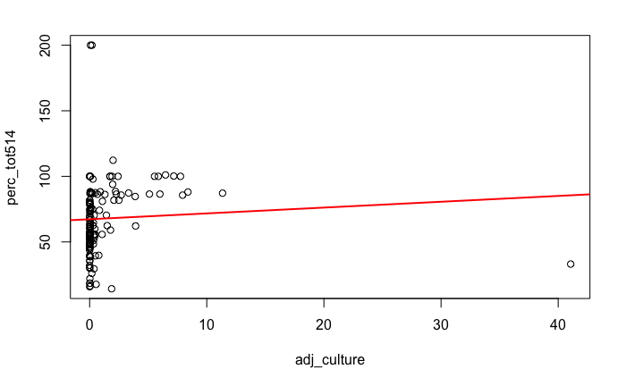

```r
plot(x = big_labequip$adj_culture, y = big_labequip$perc_tot514, xlab = "adj_culture", ylab = "perc_tot514")
abline(mod_culture_514, col = "red", lwd = 2)
```

STEP 11: Adding data for community health worker numbers (adjusting for population size)

```r
setwd("~/Desktop/AFP/TB MODELLING 2/Resource Factors")
chw <- read_csv("chw.csv")
colnames(chw) <- c("country.x", "year", "chw")
chw_2019 <- filter(chw, year == 2019)
chw_2019 <- chw_2019[, -2]

#Getting total population data from the data_bank file
setwd("~/Desktop/AFP/TB MODELLING 2/Resource Factors")
tot_pop <- read_csv("data_bank.csv")
tot_pop <- filter(tot_pop, tot_pop$`Series Name` == "Population, total")
tot_pop <- tot_pop[, -c(1:2)]
colnames(tot_pop) <- c("country", "iso3", "tot_pop_2015", "tot_pop_2016", "tot_pop_2017", "tot_pop_2018", "tot_pop_2019", "tot_pop_2020")

merge_pop <- merge(big_labequip, tot_pop, by = "iso3", all.x = TRUE)
merge_pop <- merge_pop[, -46]
lab_data <- merge_pop

#Putting the chw data into the data frame
merge_chw <- merge(merge_pop, chw_2019, by = "country.x", all.x = TRUE)
```